```python
import pandas
df = pandas.read_csv("Quotes.csv",sep=';')
df
```

|  | Date | Time | USD_RUB | Gazprom stock | Gold | Brent | Gas | Platinum | Silver | Sber stock | Lukoil stock | USD_CNY | Copper |
| --- | --- | --- | --- | --- | --- | --- | --- | --- | --- | --- | --- | --- | --- |
| 0 | 28.03.2018 | 11:00 | 57.3886 | 139.88 | 1334.1 | 69.00 | 2.700 | 938.0 | 16.395 | 253.26 | 3876.5 | 6.2770 | 6554.364990 |
| 1 | 28.03.2018 | 12:00 | 57.4609 | 140.48 | 1330.7 | 68.84 | 2.699 | 938.4 | 16.320 | 252.93 | 3896.0 | 6.2805 | 6576.411290 |
| 2 | 28.03.2018 | 13:00 | 57.5675 | 140.10 | 1329.4 | 68.93 | 2.710 | 934.7 | 16.260 | 252.59 | 3887.5 | 6.2782 | 6573.104345 |
| 3 | 28.03.2018 | 14:00 | 57.5476 | 140.12 | 1327.6 | 68.88 | 2.706 | 936.1 | 16.265 | 251.94 | 3901.5 | 6.2805 | 6587.434440 |
| 4 | 28.03.2018 | 15:00 | 57.5757 | 140.01 | 1326.7 | 69.12 | 2.701 | 935.1 | 16.270 | 252.03 | 3906.0 | 6.2870 | 6594.048330 |
| ... | ... | ... | ... | ... | ... | ... | ... | ... | ... | ... | ... | ... | ... |
| 10001 | 25.03.2022 | 12:00 | 97.5000 | 236.91 | 1956.3 | 116.23 | 5.369 | 1028.3 | 25.820 | 130.21 | 5325.0 | 6.3619 | 10426.797585 |
| 10002 | 25.03.2022 | 13:00 | 98.0000 | 228.47 | 1956.5 | 117.79 | 5.384 | 1025.7 | 25.885 | 130.86 | 5133.0 | 6.3619 | 10447.741570 |
| 10003 | 25.03.2022 | 14:00 | 98.1750 | 227.00 | 1950.4 | 117.50 | 5.480 | 1020.1 | 25.830 | 131.50 | 5206.0 | 6.3626 | 10402.546655 |
| 10004 | 28.03.2022 | 11:00 | 97.7500 | 226.16 | 1932.9 | 113.16 | 5.569 | 999.1 | 25.280 | 126.52 | 5070.5 | 6.3729 | 10329.793865 |
| 10005 | 28.03.2022 | 12:00 | 96.7250 | 225.93 | 1931.2 | 112.48 | 5.579 | 995.5 | 25.255 | 126.69 | 5166.0 | 6.3690 | 10350.737850 |

10006 rows × 13 columns

# Выбранный dataset описывает котировки на финансовом рынке, данные часовые с 28.03.2018 по 28.03.2022, все котировки синхронизированы по времени. Целевая переменная, которую будем предсказывать, -- курс доллара к рублю. Независимыми переменными или предикторами являются цена акции Газпрома, цена на золото, цена на нефть (Brent), цена на газ, цена на платину, цена на серебро, цена акции Сбера, цена акции Лукойл, курс доллара к юань.

```python
taglist = ['Gazprom stock', 'Gold', 'Brent', 'Gas',
       'Platinum', 'Silver', 'Sber stock', 'Lukoil stock', 'USD_CNY',
       'Copper']
#taglist = ['Gazprom stock','Gold', 'Silver','Platinum', 'Sber stock', 'USD_CNY', 'Copper']
X = df[taglist]
Y = df['USD_RUB']
X.head()
```

|  | Gazprom stock | Gold | Brent | Gas | Platinum | Silver | Sber stock | Lukoil stock | USD_CNY | Copper |
| --- | --- | --- | --- | --- | --- | --- | --- | --- | --- | --- |
| 0 | 139.88 | 1334.1 | 69.00 | 2.700 | 938.0 | 16.395 | 253.26 | 3876.5 | 6.2770 | 6554.364990 |
| 1 | 140.48 | 1330.7 | 68.84 | 2.699 | 938.4 | 16.320 | 252.93 | 3896.0 | 6.2805 | 6576.411290 |
| 2 | 140.10 | 1329.4 | 68.93 | 2.710 | 934.7 | 16.260 | 252.59 | 3887.5 | 6.2782 | 6573.104345 |
| 3 | 140.12 | 1327.6 | 68.88 | 2.706 | 936.1 | 16.265 | 251.94 | 3901.5 | 6.2805 | 6587.434440 |
| 4 | 140.01 | 1326.7 | 69.12 | 2.701 | 935.1 | 16.270 | 252.03 | 3906.0 | 6.2870 | 6594.048330 |

```python
from sklearn.model_selection import train_test_split

X_train, X_test, Y_train, Y_test = train_test_split(X, Y, test_size=0.3, random_state=42)
```

```python
from sklearn import *
model_LR = linear_model.LinearRegression()
LR = model_LR.fit(X_train, Y_train)
model_Ridge = linear_model.Ridge()
Ridge = model_Ridge.fit(X_train, Y_train)
model_Lasso = linear_model.Lasso()
Lasso = model_Lasso.fit(X_train, Y_train)
model_SVM = svm.SVR()
SVM = model_SVM.fit(X_train, Y_train)
```

```python
Y_pred_LR = model_LR.predict(X_test)
Y_pred_Ridge = model_Ridge.predict(X_test)
Y_pred_Lasso = model_Lasso.predict(X_test)
Y_pred_SVM = model_SVM.predict(X_test)
```

# Изобразим тестовую выборку: предсказанные значения методом линейной регрессии и истинные значения.

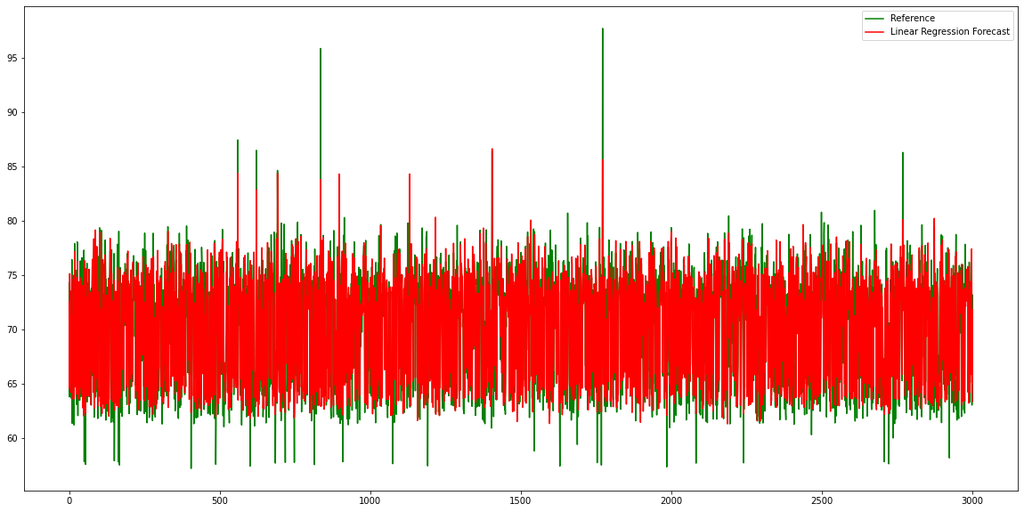

```python
import matplotlib.pyplot as plt
fig, ax=plt.subplots()
fig.set_figwidth(20)
fig.set_figheight(10)
ax.plot(range(len(Y_test)), Y_test, 'g', label = 'Reference')
ax.plot(range(len(Y_test)), Y_pred_LR, 'r',label = 'Linear Regression Forecast')
ax.legend()
plt.show()
```

# Для наглядности изобразим 300 предсказанных значений из тестовой выборки

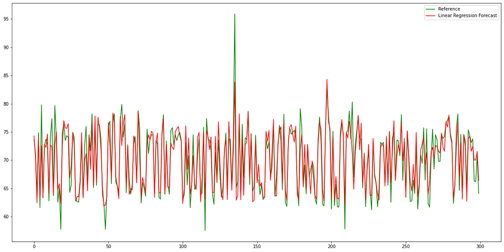

```python
fig, ax=plt.subplots()
fig.set_figwidth(20)
fig.set_figheight(10)
ax.plot(range(300), Y_test[700:1000], 'g', label = 'Reference')
ax.plot(range(300), Y_pred_LR[700:1000], 'r',label = 'Linear Regression Forecast')
ax.legend()
plt.show()
```

# В целом прогноз похож на истинные значения, т.е. целевая переменная -- курс доллара к рублю -- описывается предикторами.

# Оценим среднеквадратичную ошибку разных моделей и коэффициент детерминации.

```python
mean_squared_errors = pandas.DataFrame({
    'error LR':                     metrics.mean_squared_error(Y_test, Y_pred_LR),
    'error Ridge':                  metrics.mean_squared_error(Y_test, Y_pred_Ridge),
    'error Lasso':                  metrics.mean_squared_error(Y_test, Y_pred_Lasso),
    'error SVM':                    metrics.mean_squared_error(Y_test, Y_pred_SVM),
    }, index=range(1)
)
mean_squared_errors
```

|  | error LR | error Ridge | error Lasso | error SVM |
| --- | --- | --- | --- | --- |
| 0 | 4.156427 | 4.157049 | 4.708615 | 9.668545 |

```python
scores = pandas.DataFrame({
    'score LR':                     LR.score(X_test,Y_test),
    'score Ridge':                  Ridge.score(X_test,Y_test),
    'score Lasso':                  Lasso.score(X_test,Y_test),
    'score SVM':                    SVM.score(X_test,Y_test),
    }, index=range(1)
)
scores
```

|  | score LR | score Ridge | score Lasso | score SVM |
| --- | --- | --- | --- | --- |
| 0 | 0.855741 | 0.85572 | 0.836576 | 0.66443 |

# Чем меньше среднеквадратичная ошибка, тем лучше. Чем больше коэффициент детерминации, тем лучше. Модель линейной регресии является лучшей. Согласно коэффициенту детерминации, она описывает данные на 85.57%.

# Хорошим тоном является приведение всех значений к одному масштабу перед построением регрессии. Проделаем это, воспользовавшись двумя методами StandardScaler (стандартизация) и Normalizer (нормализация) из пакета sklearn.preprocessing.

```python
from sklearn.preprocessing import StandardScaler
model_LR = linear_model.LinearRegression()
scaled_X = StandardScaler().fit_transform(X_train)
LR_st = model_LR.fit(scaled_X, Y_train)
model_Ridge = linear_model.Ridge()
Ridge_st = model_Ridge.fit(scaled_X, Y_train)
model_Lasso = linear_model.Lasso()
Lasso_st = model_Lasso.fit(scaled_X, Y_train)
model_SVM = svm.SVR()
SVM_st = model_SVM.fit(scaled_X, Y_train)
```

```python
Y_pred_LR_st = model_LR.predict(StandardScaler().fit_transform(X_test))
Y_pred_Ridge_st = model_Ridge.predict(StandardScaler().fit_transform(X_test))
Y_pred_Lasso_st = model_Lasso.predict(StandardScaler().fit_transform(X_test))
Y_pred_SVM_st = model_SVM.predict(StandardScaler().fit_transform(X_test))
```

```python
mean_squared_errors = pandas.DataFrame({
    'error LR_stand':                     metrics.mean_squared_error(Y_test, Y_pred_LR_st),
    'error Ridge_stand':                  metrics.mean_squared_error(Y_test, Y_pred_Ridge_st),
    'error Lasso_stand':                  metrics.mean_squared_error(Y_test, Y_pred_Lasso_st),
    'error SVM_stand':                    metrics.mean_squared_error(Y_test, Y_pred_SVM_st),
    }, index=range(1)
)
mean_squared_errors
```

|  | error LR_stand | error Ridge_stand | error Lasso_stand | error SVM_stand |
| --- | --- | --- | --- | --- |
| 0 | 4.17825 | 4.178666 | 10.536896 | 0.683461 |

```python
scores = pandas.DataFrame({
    'score LR_stand':                     LR_st.score(StandardScaler().fit_transform(X_test),Y_test),
    'score Ridge_stand':                  Ridge_st.score(StandardScaler().fit_transform(X_test),Y_test),
    'score Lasso_stand':                  Lasso_st.score(StandardScaler().fit_transform(X_test),Y_test),
    'score SVM_stand':                    SVM_st.score(StandardScaler().fit_transform(X_test),Y_test),
    }, index=range(1)
)
scores
```

|  | score LR_stand | score Ridge_stand | score Lasso_stand | score SVM_stand |
| --- | --- | --- | --- | --- |
| 0 | 0.854984 | 0.85497 | 0.634292 | 0.976279 |

```python
from sklearn.preprocessing import Normalizer
model_LR = linear_model.LinearRegression()
norm_X = Normalizer().fit_transform(X_train)
LR_nrm = model_LR.fit(norm_X, Y_train)
model_Ridge = linear_model.Ridge()
Ridge_nrm = model_Ridge.fit(norm_X, Y_train)
model_Lasso = linear_model.Lasso()
Lasso_nrm = model_Lasso.fit(norm_X, Y_train)
model_SVM = svm.SVR()
SVM_nrm = model_SVM.fit(norm_X, Y_train)
```

```python
Y_pred_LR_nrm = model_LR.predict(Normalizer().fit_transform(X_test))
Y_pred_Ridge_nrm = model_Ridge.predict(Normalizer().fit_transform(X_test))
Y_pred_Lasso_nrm = model_Lasso.predict(Normalizer().fit_transform(X_test))
Y_pred_SVM_nrm = model_SVM.predict(Normalizer().fit_transform(X_test))
```

```python
mean_squared_errors = pandas.DataFrame({
    'error LR_norm':                     metrics.mean_squared_error(Y_test, Y_pred_LR_nrm),
    'error Ridge_norm':                  metrics.mean_squared_error(Y_test, Y_pred_Ridge_nrm),
    'error Lasso_norm':                  metrics.mean_squared_error(Y_test, Y_pred_Lasso_nrm),
    'error SVM_norm':                    metrics.mean_squared_error(Y_test, Y_pred_SVM_nrm),
    }, index=range(1)
)
mean_squared_errors
```

|  | error LR_norm | error Ridge_norm | error Lasso_norm | error SVM_norm |
| --- | --- | --- | --- | --- |
| 0 | 4.091829 | 14.427394 | 28.83045 | 17.25414 |

```python
scores = pandas.DataFrame({
    'score LR_norm':                     LR_nrm.score(Normalizer().fit_transform(X_test),Y_test),
    'score Ridge_norm':                  Ridge_nrm.score(Normalizer().fit_transform(X_test),Y_test),
    'score Lasso_norm':                  Lasso_nrm.score(Normalizer().fit_transform(X_test),Y_test),
    'score SVM_norm':                    SVM_nrm.score(Normalizer().fit_transform(X_test),Y_test),
    }, index=range(1)
)
scores
```

|  | score LR_norm | score Ridge_norm | score Lasso_norm | score SVM_norm |
| --- | --- | --- | --- | --- |
| 0 | 0.857983 | 0.499263 | -0.000629 | 0.401154 |

# Со стандартизацией результат оказался чуть хуже по сравнению с обычной регрессией без предварительного приведения масштабов, с нормализацией -- чуть лучше, однако на рисунке улучшение не заметно.

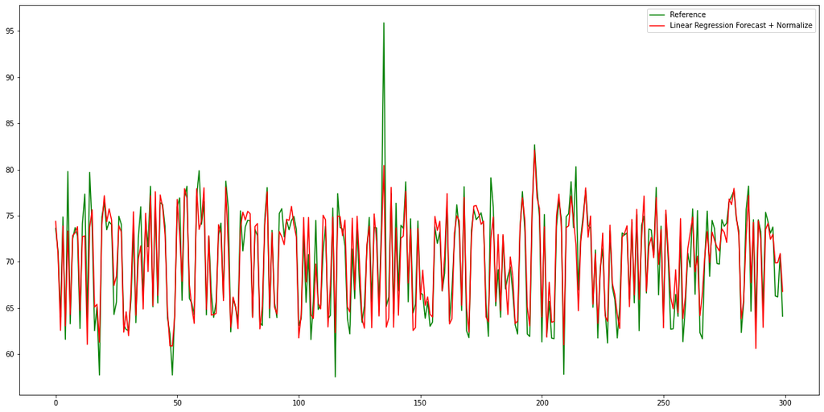

```python
fig, ax=plt.subplots()
fig.set_figwidth(20)
fig.set_figheight(10)
ax.plot(range(300), Y_test[700:1000], 'g', label = 'Reference')
ax.plot(range(300), Y_pred_LR_nrm[700:1000], 'r',label = 'Linear Regression Forecast + Normalize')
ax.legend()
plt.show()
```

# До этого рассматривалась задача, в которой курс доллара (допустим завтрашний) прогнозируется по завтрашним значениям цен на золото, нефть и т.д. (эти цены очевидно неизвестны), поэтому такая задача не совсем корректна. Поэтому попробуем спрогнозировать завтрашний курс доллара по сегодняшним (по значениям на предыдущий день) ценам предикторов. Также добавим дополнительный предиктор -- курс доллара на предыдущий день, т.е. при прогнозировании курса на завтра будем учитывать какой курс сегодня, это значение очевидно известно. Этот новый предиктор USD_RUB_prev будет очень сильно коррелировать с целевой переменной USD_RUB.

```python
df2 = df.copy().loc[:len(df.index)-2]
df2['USD_RUB'] = list(df.loc[1:,'USD_RUB'])
df2['USD_RUB_prev'] = list(df.loc[:len(df.index)-2,'USD_RUB'])
df2
```

|  | Date | Time | USD_RUB | Gazprom stock | Gold | Brent | Gas | Platinum | Silver | Sber stock | Lukoil stock | USD_CNY | Copper | USD_RUB_prev |
| --- | --- | --- | --- | --- | --- | --- | --- | --- | --- | --- | --- | --- | --- | --- |
| 0 | 28.03.2018 | 11:00 | 57.4609 | 139.88 | 1334.1 | 69.00 | 2.700 | 938.0 | 16.395 | 253.26 | 3876.5 | 6.2770 | 6554.364990 | 57.3886 |
| 1 | 28.03.2018 | 12:00 | 57.5675 | 140.48 | 1330.7 | 68.84 | 2.699 | 938.4 | 16.320 | 252.93 | 3896.0 | 6.2805 | 6576.411290 | 57.4609 |
| 2 | 28.03.2018 | 13:00 | 57.5476 | 140.10 | 1329.4 | 68.93 | 2.710 | 934.7 | 16.260 | 252.59 | 3887.5 | 6.2782 | 6573.104345 | 57.5675 |
| 3 | 28.03.2018 | 14:00 | 57.5757 | 140.12 | 1327.6 | 68.88 | 2.706 | 936.1 | 16.265 | 251.94 | 3901.5 | 6.2805 | 6587.434440 | 57.5476 |
| 4 | 28.03.2018 | 15:00 | 57.5717 | 140.01 | 1326.7 | 69.12 | 2.701 | 935.1 | 16.270 | 252.03 | 3906.0 | 6.2870 | 6594.048330 | 57.5757 |
| ... | ... | ... | ... | ... | ... | ... | ... | ... | ... | ... | ... | ... | ... | ... |
| 10000 | 25.03.2022 | 11:00 | 97.5000 | 248.74 | 1955.2 | 117.32 | 5.413 | 1029.5 | 25.810 | 131.65 | 5406.0 | 6.3631 | 10509.471210 | 98.5000 |
| 10001 | 25.03.2022 | 12:00 | 98.0000 | 236.91 | 1956.3 | 116.23 | 5.369 | 1028.3 | 25.820 | 130.21 | 5325.0 | 6.3619 | 10426.797585 | 97.5000 |
| 10002 | 25.03.2022 | 13:00 | 98.1750 | 228.47 | 1956.5 | 117.79 | 5.384 | 1025.7 | 25.885 | 130.86 | 5133.0 | 6.3619 | 10447.741570 | 98.0000 |
| 10003 | 25.03.2022 | 14:00 | 97.7500 | 227.00 | 1950.4 | 117.50 | 5.480 | 1020.1 | 25.830 | 131.50 | 5206.0 | 6.3626 | 10402.546655 | 98.1750 |
| 10004 | 28.03.2022 | 11:00 | 96.7250 | 226.16 | 1932.9 | 113.16 | 5.569 | 999.1 | 25.280 | 126.52 | 5070.5 | 6.3729 | 10329.793865 | 97.7500 |

10005 rows × 14 columns

```python
corr = df2.corr()
corr.style.background_gradient(cmap='coolwarm')
```

|  | USD_RUB | Gazprom stock | Gold | Brent | Gas | Platinum | Silver | Sber stock | Lukoil stock | USD_CNY | Copper | USD_RUB_prev |
| --- | --- | --- | --- | --- | --- | --- | --- | --- | --- | --- | --- | --- |
| USD_RUB | 1.000000 | 0.353429 | 0.812956 | -0.172669 | 0.270200 | 0.432261 | 0.738444 | 0.313541 | 0.243111 | -0.385641 | 0.568936 | 0.999020 |
| Gazprom stock | 0.353429 | 1.000000 | 0.521107 | 0.440546 | 0.626515 | 0.484455 | 0.487413 | 0.819121 | 0.887863 | -0.449446 | 0.730718 | 0.353730 |
| Gold | 0.812956 | 0.521107 | 1.000000 | -0.250922 | 0.146549 | 0.583652 | 0.882626 | 0.521063 | 0.407741 | -0.338316 | 0.572598 | 0.813379 |
| Brent | -0.172669 | 0.440546 | -0.250922 | 1.000000 | 0.683117 | 0.288564 | 0.019384 | 0.391856 | 0.453236 | -0.585130 | 0.552796 | -0.173783 |
| Gas | 0.270200 | 0.626515 | 0.146549 | 0.683117 | 1.000000 | 0.265815 | 0.289493 | 0.575425 | 0.533499 | -0.639457 | 0.693718 | 0.270152 |
| Platinum | 0.432261 | 0.484455 | 0.583652 | 0.288564 | 0.265815 | 1.000000 | 0.812340 | 0.697795 | 0.551336 | -0.617528 | 0.772952 | 0.432343 |
| Silver | 0.738444 | 0.487413 | 0.882626 | 0.019384 | 0.289493 | 0.812340 | 1.000000 | 0.649710 | 0.431904 | -0.575296 | 0.752222 | 0.738942 |
| Sber stock | 0.313541 | 0.819121 | 0.521063 | 0.391856 | 0.575425 | 0.697795 | 0.649710 | 1.000000 | 0.788010 | -0.643769 | 0.817059 | 0.314530 |
| Lukoil stock | 0.243111 | 0.887863 | 0.407741 | 0.453236 | 0.533499 | 0.551336 | 0.431904 | 0.788010 | 1.000000 | -0.377324 | 0.674204 | 0.243487 |
| USD_CNY | -0.385641 | -0.449446 | -0.338316 | -0.585130 | -0.639457 | -0.617528 | -0.575296 | -0.643769 | -0.377324 | 1.000000 | -0.858480 | -0.385355 |
| Copper | 0.568936 | 0.730718 | 0.572598 | 0.552796 | 0.693718 | 0.772952 | 0.752222 | 0.817059 | 0.674204 | -0.858480 | 1.000000 | 0.568982 |
| USD_RUB_prev | 0.999020 | 0.353730 | 0.813379 | -0.173783 | 0.270152 | 0.432343 | 0.738942 | 0.314530 | 0.243487 | -0.385355 | 0.568982 | 1.000000 |

```python
X = df2[taglist+['USD_RUB_prev']]
Y = df2['USD_RUB']
X_train, X_test, Y_train, Y_test = train_test_split(X, Y, test_size=0.3, random_state=42)
model_LR = linear_model.LinearRegression()
LR = model_LR.fit(X_train, Y_train)
model_Ridge = linear_model.Ridge()
Ridge = model_Ridge.fit(X_train, Y_train)
model_Lasso = linear_model.Lasso()
Lasso = model_Lasso.fit(X_train, Y_train)
model_SVM = svm.SVR()
SVM = model_SVM.fit(X_train, Y_train)
```

```python
Y_pred_LR = model_LR.predict(X_test)
Y_pred_Ridge = model_Ridge.predict(X_test)
Y_pred_Lasso = model_Lasso.predict(X_test)
Y_pred_SVM = model_SVM.predict(X_test)
```

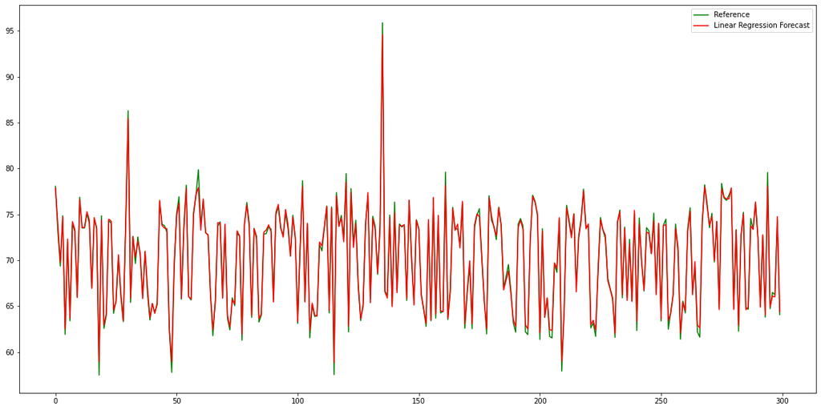

```python
fig, ax=plt.subplots()
fig.set_figwidth(20)
fig.set_figheight(10)
ax.plot(range(300), Y_test[700:1000], 'g', label = 'Reference')
ax.plot(range(300), Y_pred_Lasso[700:1000], 'r',label = 'Linear Regression Forecast')
ax.legend()
plt.show()
```

# Визуально результат практически идеальный. Ошибка тоже маленькая, а коэффициент детерминации говорит, что модель описывает данные на 99.79%.

```python
mean_squared_errors = pandas.DataFrame({
    'error LR':                     metrics.mean_squared_error(Y_test, Y_pred_LR),
    'error Ridge':                  metrics.mean_squared_error(Y_test, Y_pred_Ridge),
    'error Lasso':                  metrics.mean_squared_error(Y_test, Y_pred_Lasso),
    'error SVM':                    metrics.mean_squared_error(Y_test, Y_pred_SVM),
    }, index=range(1)
)
mean_squared_errors
```

|  | error LR | error Ridge | error Lasso | error SVM |
| --- | --- | --- | --- | --- |
| 0 | 0.059495 | 0.059492 | 0.216314 | 9.834422 |

```python
scores = pandas.DataFrame({
    'score LR':                     LR.score(X_test,Y_test),
    'score Ridge':                  Ridge.score(X_test,Y_test),
    'score Lasso':                  Lasso.score(X_test,Y_test),
    'score SVM':                    SVM.score(X_test,Y_test),
    }, index=range(1)
)
scores
```

|  | score LR | score Ridge | score Lasso | score SVM |
| --- | --- | --- | --- | --- |
| 0 | 0.997952 | 0.997952 | 0.992554 | 0.66146 |

# Такой же по качеству результат получится, если строить регрессию только от одного предиктора -- от предыдущего значения курса доллара. Это называется авторегрессия первого порядка.

```python
X = df2[['USD_RUB_prev']]
Y = df2['USD_RUB']
X_train, X_test, Y_train, Y_test = train_test_split(X, Y, test_size=0.3, random_state=42)
model_LR = linear_model.LinearRegression()
LR = model_LR.fit(X_train, Y_train)
model_Ridge = linear_model.Ridge()
Ridge = model_Ridge.fit(X_train, Y_train)
model_Lasso = linear_model.Lasso()
Lasso = model_Lasso.fit(X_train, Y_train)
model_SVM = svm.SVR()
SVM = model_SVM.fit(X_train, Y_train)
```

```python
Y_pred_LR = model_LR.predict(X_test)
Y_pred_Ridge = model_Ridge.predict(X_test)
Y_pred_Lasso = model_Lasso.predict(X_test)
Y_pred_SVM = model_SVM.predict(X_test)
```

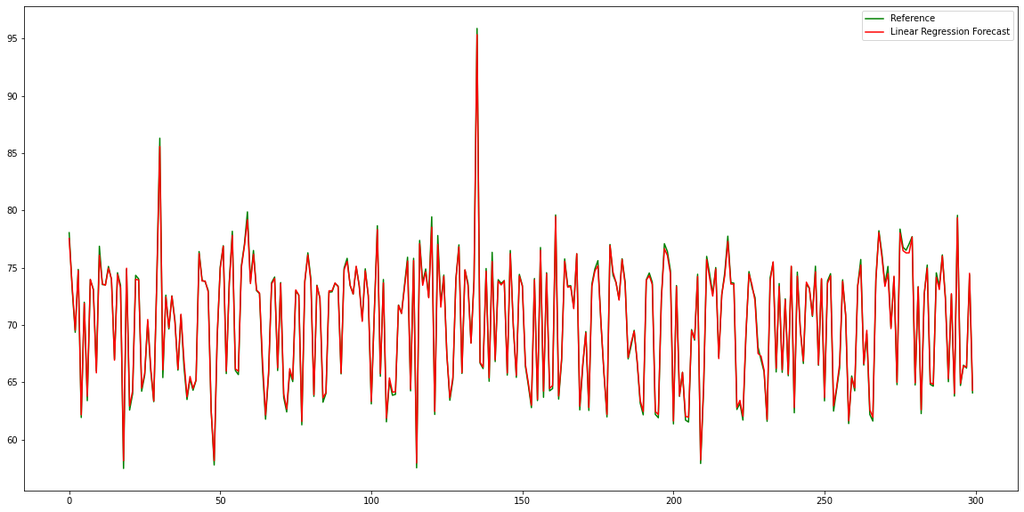

```python
fig, ax=plt.subplots()
fig.set_figwidth(20)
fig.set_figheight(10)
ax.plot(range(300), Y_test[700:1000], 'g', label = 'Reference')
ax.plot(range(300), Y_pred_Lasso[700:1000], 'r',label = 'Linear Regression Forecast')
ax.legend()
plt.show()
```

```python
mean_squared_errors = pandas.DataFrame({
    'error LR':                     metrics.mean_squared_error(Y_test, Y_pred_LR),
    'error Ridge':                  metrics.mean_squared_error(Y_test, Y_pred_Ridge),
    'error Lasso':                  metrics.mean_squared_error(Y_test, Y_pred_Lasso),
    'error SVM':                    metrics.mean_squared_error(Y_test, Y_pred_SVM),
    }, index=range(1)
)
mean_squared_errors
```

|  | error LR | error Ridge | error Lasso | error SVM |
| --- | --- | --- | --- | --- |
| 0 | 0.059408 | 0.059407 | 0.089935 | 0.615644 |

```python
scores = pandas.DataFrame({
    'score LR':                     LR.score(X_test,Y_test),
    'score Ridge':                  Ridge.score(X_test,Y_test),
    'score Lasso':                  Lasso.score(X_test,Y_test),
    'score SVM':                    SVM.score(X_test,Y_test),
    }, index=range(1)
)
scores
```

|  | score LR | score Ridge | score Lasso | score SVM |
| --- | --- | --- | --- | --- |
| 0 | 0.997955 | 0.997955 | 0.996904 | 0.978807 |

```python
!jupyter nbconvert --execute --to html Project_ML_Lagno.ipynb
```

```
[NbConvertApp] Converting notebook Project_ML_Lagno.ipynb to html
[NbConvertApp] Writing 1652840 bytes to Project_ML_Lagno.html
```